# Breast Cancer: Malignant or Benign? Using SHAP values to examine feature importance of physical characteristics and make predictions

We have a dataset on whether a breast cancer was classified as malignant or benign in addition to various features for each.

With this data, it would be nice to have a model that is able to make predictions on the diagnosis based on these physical features.

A practical application of this would be to examine the features, and identify which seem to be most correlated with malignant cancers.

This could help medical providers determine what physical characteristics to look for most, make decisions, and reinforce their professional intuition to make decisions. For patients, this may identify useful rule-of-thumb characteristics to immediately contact their healthcare provider about, such as a change in texture. For researchers, this may identify features that spending the effort to collect data for is not very fruitful.

Data: https://www.kaggle.com/datasets/nancyalaswad90/breast-cancer-dataset

## Contents of Notebook

1. Import Libraries
2. Data exploration and cleaning, Check for missing values
3. Feature exploration/Check for multicollinearity
4. Train Logistic Regression Model
5. Train Neural Net
6. Compare results of the classidffication algorithms
7. Interpret model with Feature importance and SHAP values
8. Visualize feature contribution
9. SHAP breakdown for an individual example (a patient)
10. Summary

## Import libraries

```python
import pandas as pd
import numpy as np
import matplotlib.pyplot as plt
import seaborn as sns
import tensorflow as tf
import xgboost
import shap


from sklearn.linear_model import LogisticRegressionCV
from sklearn.model_selection import train_test_split
from sklearn import preprocessing
from sklearn.model_selection import cross_val_score
from sklearn.ensemble import RandomForestClassifier
from sklearn.metrics import accuracy_score, classification_report
from xgboost import XGBClassifier

from pdpbox import pdp, get_dataset, info_plots

from tensorflow import keras
from tensorflow.keras import layers
```

```python
df = pd.read_csv("Breast_Cancer_Wisconsin_Diagnostic_Dataset.csv")
```

```python
df.head()
```

|  | id | diagnosis | radius_mean | texture_mean | perimeter_mean | area_mean | smoothness_mean | compactness_mean | concavity_mean | concave_points_mean | ... | radius_worst | texture_worst | perimeter_worst | area_worst | smoothness_worst | compactness_worst | concavity_worst | concave_points_worst | symmetry_worst | fractal_dimension_worst |
| --- | --- | --- | --- | --- | --- | --- | --- | --- | --- | --- | --- | --- | --- | --- | --- | --- | --- | --- | --- | --- | --- |
| 0 | 842302 | M | 17.99 | 10.38 | 122.80 | 1001.0 | 0.11840 | 0.27760 | 0.3001 | 0.14710 | ... | 25.38 | 17.33 | 184.60 | 2019.0 | 0.1622 | 0.6656 | 0.7119 | 0.2654 | 0.4601 | 0.11890 |
| 1 | 842517 | M | 20.57 | 17.77 | 132.90 | 1326.0 | 0.08474 | 0.07864 | 0.0869 | 0.07017 | ... | 24.99 | 23.41 | 158.80 | 1956.0 | 0.1238 | 0.1866 | 0.2416 | 0.1860 | 0.2750 | 0.08902 |
| 2 | 84300903 | M | 19.69 | 21.25 | 130.00 | 1203.0 | 0.10960 | 0.15990 | 0.1974 | 0.12790 | ... | 23.57 | 25.53 | 152.50 | 1709.0 | 0.1444 | 0.4245 | 0.4504 | 0.2430 | 0.3613 | 0.08758 |
| 3 | 84348301 | M | 11.42 | 20.38 | 77.58 | 386.1 | 0.14250 | 0.28390 | 0.2414 | 0.10520 | ... | 14.91 | 26.50 | 98.87 | 567.7 | 0.2098 | 0.8663 | 0.6869 | 0.2575 | 0.6638 | 0.17300 |
| 4 | 84358402 | M | 20.29 | 14.34 | 135.10 | 1297.0 | 0.10030 | 0.13280 | 0.1980 | 0.10430 | ... | 22.54 | 16.67 | 152.20 | 1575.0 | 0.1374 | 0.2050 | 0.4000 | 0.1625 | 0.2364 | 0.07678 |

5 rows × 32 columns

Making the new index the id column, and split the data into X and y.

All features are numerical, no need to separate from any categorical features.

```python
clean_df = df.copy().dropna().set_index('id')
X = clean_df.drop('diagnosis', axis=1)
y = clean_df.diagnosis
```

## Dataset Exploration

```python
#view features
X.head()
```

| id | radius_mean | texture_mean | perimeter_mean | area_mean | smoothness_mean | compactness_mean | concavity_mean | concave_points_mean | symmetry_mean | fractal_dimension_mean | ... | radius_worst | texture_worst | perimeter_worst | area_worst | smoothness_worst | compactness_worst | concavity_worst | concave_points_worst | symmetry_worst | fractal_dimension_worst |
| --- | --- | --- | --- | --- | --- | --- | --- | --- | --- | --- | --- | --- | --- | --- | --- | --- | --- | --- | --- | --- | --- |
| 842302 | 17.99 | 10.38 | 122.80 | 1001.0 | 0.11840 | 0.27760 | 0.3001 | 0.14710 | 0.2419 | 0.07871 | ... | 25.38 | 17.33 | 184.60 | 2019.0 | 0.1622 | 0.6656 | 0.7119 | 0.2654 | 0.4601 | 0.11890 |
| 842517 | 20.57 | 17.77 | 132.90 | 1326.0 | 0.08474 | 0.07864 | 0.0869 | 0.07017 | 0.1812 | 0.05667 | ... | 24.99 | 23.41 | 158.80 | 1956.0 | 0.1238 | 0.1866 | 0.2416 | 0.1860 | 0.2750 | 0.08902 |
| 84300903 | 19.69 | 21.25 | 130.00 | 1203.0 | 0.10960 | 0.15990 | 0.1974 | 0.12790 | 0.2069 | 0.05999 | ... | 23.57 | 25.53 | 152.50 | 1709.0 | 0.1444 | 0.4245 | 0.4504 | 0.2430 | 0.3613 | 0.08758 |
| 84348301 | 11.42 | 20.38 | 77.58 | 386.1 | 0.14250 | 0.28390 | 0.2414 | 0.10520 | 0.2597 | 0.09744 | ... | 14.91 | 26.50 | 98.87 | 567.7 | 0.2098 | 0.8663 | 0.6869 | 0.2575 | 0.6638 | 0.17300 |
| 84358402 | 20.29 | 14.34 | 135.10 | 1297.0 | 0.10030 | 0.13280 | 0.1980 | 0.10430 | 0.1809 | 0.05883 | ... | 22.54 | 16.67 | 152.20 | 1575.0 | 0.1374 | 0.2050 | 0.4000 | 0.1625 | 0.2364 | 0.07678 |

5 rows × 30 columns

```python
#view target
y.head()
```

```
id
842302      M
842517      M
84300903    M
84348301    M
84358402    M
Name: diagnosis, dtype: object
```

output variable is diagnosis.

broadly, several variables are related to size, shape, and texture.

other variables mention "worst" or "mean" which may be an interesting place to look for some feature engineering later

```python
print('the shape of the cleaned df is ' + str(clean_df.shape))
print('the shape of X is ' + str(X.shape))
```

```
the shape of the cleaned df is (569, 31)
the shape of X is (569, 30)
```

The shape of the data is 569 examples. Not counting the id and diagnosis, there are 30 features.

```python
#view dataframe summary
df.info()
```

```
<class 'pandas.core.frame.DataFrame'>
RangeIndex: 569 entries, 0 to 568
Data columns (total 32 columns):
 #   Column                   Non-Null Count  Dtype
---  ------                   --------------  -----
 0   id                       569 non-null    int64
 1   diagnosis                569 non-null    object
 2   radius_mean              569 non-null    float64
 3   texture_mean             569 non-null    float64
 4   perimeter_mean           569 non-null    float64
 5   area_mean                569 non-null    float64
 6   smoothness_mean          569 non-null    float64
 7   compactness_mean         569 non-null    float64
 8   concavity_mean           569 non-null    float64
 9   concave_points_mean      569 non-null    float64
```

[output cut: 24 more lines]

All of the names of the features in a list. Each has 569 non-null entries, so there is no missing data.

```python
X.describe()
```

|  | radius_mean | texture_mean | perimeter_mean | area_mean | smoothness_mean | compactness_mean | concavity_mean | concave_points_mean | symmetry_mean | fractal_dimension_mean | ... | radius_worst | texture_worst | perimeter_worst | area_worst | smoothness_worst | compactness_worst | concavity_worst | concave_points_worst | symmetry_worst | fractal_dimension_worst |
| --- | --- | --- | --- | --- | --- | --- | --- | --- | --- | --- | --- | --- | --- | --- | --- | --- | --- | --- | --- | --- | --- |
| count | 569.000000 | 569.000000 | 569.000000 | 569.000000 | 569.000000 | 569.000000 | 569.000000 | 569.000000 | 569.000000 | 569.000000 | ... | 569.000000 | 569.000000 | 569.000000 | 569.000000 | 569.000000 | 569.000000 | 569.000000 | 569.000000 | 569.000000 | 569.000000 |
| mean | 14.127292 | 19.289649 | 91.969033 | 654.889104 | 0.096360 | 0.104341 | 0.088799 | 0.048919 | 0.181162 | 0.062798 | ... | 16.269190 | 25.677223 | 107.261213 | 880.583128 | 0.132369 | 0.254265 | 0.272188 | 0.114606 | 0.290076 | 0.083946 |
| std | 3.524049 | 4.301036 | 24.298981 | 351.914129 | 0.014064 | 0.052813 | 0.079720 | 0.038803 | 0.027414 | 0.007060 | ... | 4.833242 | 6.146258 | 33.602542 | 569.356993 | 0.022832 | 0.157336 | 0.208624 | 0.065732 | 0.061867 | 0.018061 |
| min | 6.981000 | 9.710000 | 43.790000 | 143.500000 | 0.052630 | 0.019380 | 0.000000 | 0.000000 | 0.106000 | 0.049960 | ... | 7.930000 | 12.020000 | 50.410000 | 185.200000 | 0.071170 | 0.027290 | 0.000000 | 0.000000 | 0.156500 | 0.055040 |
| 25% | 11.700000 | 16.170000 | 75.170000 | 420.300000 | 0.086370 | 0.064920 | 0.029560 | 0.020310 | 0.161900 | 0.057700 | ... | 13.010000 | 21.080000 | 84.110000 | 515.300000 | 0.116600 | 0.147200 | 0.114500 | 0.064930 | 0.250400 | 0.071460 |
| 50% | 13.370000 | 18.840000 | 86.240000 | 551.100000 | 0.095870 | 0.092630 | 0.061540 | 0.033500 | 0.179200 | 0.061540 | ... | 14.970000 | 25.410000 | 97.660000 | 686.500000 | 0.131300 | 0.211900 | 0.226700 | 0.099930 | 0.282200 | 0.080040 |
| 75% | 15.780000 | 21.800000 | 104.100000 | 782.700000 | 0.105300 | 0.130400 | 0.130700 | 0.074000 | 0.195700 | 0.066120 | ... | 18.790000 | 29.720000 | 125.400000 | 1084.000000 | 0.146000 | 0.339100 | 0.382900 | 0.161400 | 0.317900 | 0.092080 |
| max | 28.110000 | 39.280000 | 188.500000 | 2501.000000 | 0.163400 | 0.345400 | 0.426800 | 0.201200 | 0.304000 | 0.097440 | ... | 36.040000 | 49.540000 | 251.200000 | 4254.000000 | 0.222600 | 1.058000 | 1.252000 | 0.291000 | 0.663800 | 0.207500 |

8 rows × 30 columns

## Feature Exploration

Mny features pertained to size, shape, and texture of a tumor. It makes sense that many of these are correlated and that is worth looking into.

We can use a heatmap to quickly visualize the relationsip between features, and a correlation matrix to check the exact values.

```python
#matrix of correlated variables
corr = df.corr()
corr.style.background_gradient(cmap='coolwarm')
```

|  | id | radius_mean | texture_mean | perimeter_mean | area_mean | smoothness_mean | compactness_mean | concavity_mean | concave_points_mean | symmetry_mean | fractal_dimension_mean | radius_se | texture_se | perimeter_se | area_se | smoothness_se | compactness_se | concavity_se | concave_points_se | symmetry_se | fractal_dimension_se | radius_worst | texture_worst | perimeter_worst | area_worst | smoothness_worst | compactness_worst | concavity_worst | concave_points_worst | … |
| --- | --- | --- | --- | --- | --- | --- | --- | --- | --- | --- | --- | --- | --- | --- | --- | --- | --- | --- | --- | --- | --- | --- | --- | --- | --- | --- | --- | --- | --- | --- |
| id | 1.000000 | 0.074626 | 0.099770 | 0.073159 | 0.096893 | -0.012968 | 0.000096 | 0.050080 | 0.044158 | -0.022114 | -0.052511 | 0.143048 | -0.007526 | 0.137331 | 0.177742 | 0.096781 | 0.033961 | 0.055239 | 0.078768 | -0.017306 | 0.025725 | 0.082405 | 0.064720 | 0.079986 | 0.107187 | 0.010338 | -0.002968 | 0.023203 | 0.035174 | … |
| radius_mean | 0.074626 | 1.000000 | 0.323782 | 0.997855 | 0.987357 | 0.170581 | 0.506124 | 0.676764 | 0.822529 | 0.147741 | -0.311631 | 0.679090 | -0.097317 | 0.674172 | 0.735864 | -0.222600 | 0.206000 | 0.194204 | 0.376169 | -0.104321 | -0.042641 | 0.969539 | 0.297008 | 0.965137 | 0.941082 | 0.119616 | 0.413463 | 0.526911 | 0.744214 | … |
| texture_mean | 0.099770 | 0.323782 | 1.000000 | 0.329533 | 0.321086 | -0.023389 | 0.236702 | 0.302418 | 0.293464 | 0.071401 | -0.076437 | 0.275869 | 0.386358 | 0.281673 | 0.259845 | 0.006614 | 0.191975 | 0.143293 | 0.163851 | 0.009127 | 0.054458 | 0.352573 | 0.912045 | 0.358040 | 0.343546 | 0.077503 | 0.277830 | 0.301025 | 0.295316 | … |
| perimeter_mean | 0.073159 | 0.997855 | 0.329533 | 1.000000 | 0.986507 | 0.207278 | 0.556936 | 0.716136 | 0.850977 | 0.183027 | -0.261477 | 0.691765 | -0.086761 | 0.693135 | 0.744983 | -0.202694 | 0.250744 | 0.228082 | 0.407217 | -0.081629 | -0.005523 | 0.969476 | 0.303038 | 0.970387 | 0.941550 | 0.150549 | 0.455774 | 0.563879 | 0.771241 | … |
| area_mean | 0.096893 | 0.987357 | 0.321086 | 0.986507 | 1.000000 | 0.177028 | 0.498502 | 0.685983 | 0.823269 | 0.151293 | -0.283110 | 0.732562 | -0.066280 | 0.726628 | 0.800086 | -0.166777 | 0.212583 | 0.207660 | 0.372320 | -0.072497 | -0.019887 | 0.962746 | 0.287489 | 0.959120 | 0.959213 | 0.123523 | 0.390410 | 0.512606 | 0.722017 | … |
| smoothness_mean | -0.012968 | 0.170581 | -0.023389 | 0.207278 | 0.177028 | 1.000000 | 0.659123 | 0.521984 | 0.553695 | 0.557775 | 0.584792 | 0.301467 | 0.068406 | 0.296092 | 0.246552 | 0.332375 | 0.318943 | 0.248396 | 0.380676 | 0.200774 | 0.283607 | 0.213120 | 0.036072 | 0.238853 | 0.206718 | 0.805324 | 0.472468 | 0.434926 | 0.503053 | … |
| compactness_mean | 0.000096 | 0.506124 | 0.236702 | 0.556936 | 0.498502 | 0.659123 | 1.000000 | 0.883121 | 0.831135 | 0.602641 | 0.565369 | 0.497473 | 0.046205 | 0.548905 | 0.455653 | 0.135299 | 0.738722 | 0.570517 | 0.642262 | 0.229977 | 0.507318 | 0.535315 | 0.248133 | 0.590210 | 0.509604 | 0.565541 | 0.865809 | 0.816275 | 0.815573 | … |
| concavity_mean | 0.050080 | 0.676764 | 0.302418 | 0.716136 | 0.685983 | 0.521984 | 0.883121 | 1.000000 | 0.921391 | 0.500667 | 0.336783 | 0.631925 | 0.076218 | 0.660391 | 0.617427 | 0.098564 | 0.670279 | 0.691270 | 0.683260 | 0.178009 | 0.449301 | 0.688236 | 0.299879 | 0.729565 | 0.675987 | 0.448822 | 0.754968 | 0.884103 | 0.861323 | … |
| concave_points_mean | 0.044158 | 0.822529 | 0.293464 | 0.850977 | 0.823269 | 0.553695 | 0.831135 | 0.921391 | 1.000000 | 0.462497 | 0.166917 | 0.698050 | 0.021480 | 0.710650 | 0.690299 | 0.027653 | 0.490424 | 0.439167 | 0.615634 | 0.095351 | 0.257584 | 0.830318 | 0.292752 | 0.855923 | 0.809630 | 0.452753 | 0.667454 | 0.752399 | 0.910155 | … |
| symmetry_mean | -0.022114 | 0.147741 | 0.071401 | 0.183027 | 0.151293 | 0.557775 | 0.602641 | 0.500667 | 0.462497 | 1.000000 | 0.479921 | 0.303379 | 0.128053 | 0.313893 | 0.223970 | 0.187321 | 0.421659 | 0.342627 | 0.393298 | 0.449137 | 0.331786 | 0.185728 | 0.090651 | 0.219169 | 0.177193 | 0.426675 | 0.473200 | 0.433721 | 0.430297 | … |
| fractal_dimension_mean | -0.052511 | -0.311631 | -0.076437 | -0.261477 | -0.283110 | 0.584792 | 0.565369 | 0.336783 | 0.166917 | 0.479921 | 1.000000 | 0.000111 | 0.164174 | 0.039830 | -0.090170 | 0.401964 | 0.559837 | 0.446630 | 0.341198 | 0.345007 | 0.688132 | -0.253691 | -0.051269 | -0.205151 | -0.231854 | 0.504942 | 0.458798 | 0.346234 | 0.175325 | … |
| radius_se | 0.143048 | 0.679090 | 0.275869 | 0.691765 | 0.732562 | 0.301467 | 0.497473 | 0.631925 | 0.698050 | 0.303379 | 0.000111 | 1.000000 | 0.213247 | 0.972794 | 0.951830 | 0.164514 | 0.356065 | 0.332358 | 0.513346 | 0.240567 | 0.227754 | 0.715065 | 0.194799 | 0.719684 | 0.751548 | 0.141919 | 0.287103 | 0.380585 | 0.531062 | … |
| texture_se | -0.007526 | -0.097317 | 0.386358 | -0.086761 | -0.066280 | 0.068406 | 0.046205 | 0.076218 | 0.021480 | 0.128053 | 0.164174 | 0.213247 | 1.000000 | 0.223171 | 0.111567 | 0.397243 | 0.231700 | 0.194998 | 0.230283 | 0.411621 | 0.279723 | -0.111690 | 0.409003 | -0.102242 | -0.083195 | -0.073658 | -0.092439 | -0.068956 | -0.119638 | … |
| perimeter_se | 0.137331 | 0.674172 | 0.281673 | 0.693135 | 0.726628 | 0.296092 | 0.548905 | 0.660391 | 0.710650 | 0.313893 | 0.039830 | 0.972794 | 0.223171 | 1.000000 | 0.937655 | 0.151075 | 0.416322 | 0.362482 | 0.556264 | 0.266487 | 0.244143 | 0.697201 | 0.200371 | 0.721031 | 0.730713 | 0.130054 | 0.341919 | 0.418899 | 0.554897 | … |
| area_se | 0.177742 | 0.735864 | 0.259845 | 0.744983 | 0.800086 | 0.246552 | 0.455653 | 0.617427 | 0.690299 | 0.223970 | -0.090170 | 0.951830 | 0.111567 | 0.937655 | 1.000000 | 0.075150 | 0.284840 | 0.270895 | 0.415730 | 0.134109 | 0.127071 | 0.757373 | 0.196497 | 0.761213 | 0.811408 | 0.125389 | 0.283257 | 0.385100 | 0.538166 | … |
| smoothness_se | 0.096781 | -0.222600 | 0.006614 | -0.202694 | -0.166777 | 0.332375 | 0.135299 | 0.098564 | 0.027653 | 0.187321 | 0.401964 | 0.164514 | 0.397243 | 0.151075 | 0.075150 | 1.000000 | 0.336696 | 0.268685 | 0.328429 | 0.413506 | 0.427374 | -0.230691 | -0.074743 | -0.217304 | -0.182195 | 0.314457 | -0.055558 | -0.058298 | -0.102007 | … |
| compactness_se | 0.033961 | 0.206000 | 0.191975 | 0.250744 | 0.212583 | 0.318943 | 0.738722 | 0.670279 | 0.490424 | 0.421659 | 0.559837 | 0.356065 | 0.231700 | 0.416322 | 0.284840 | 0.336696 | 1.000000 | 0.801268 | 0.744083 | 0.394713 | 0.803269 | 0.204607 | 0.143003 | 0.260516 | 0.199371 | 0.227394 | 0.678780 | 0.639147 | 0.483208 | … |
| concavity_se | 0.055239 | 0.194204 | 0.143293 | 0.228082 | 0.207660 | 0.248396 | 0.570517 | 0.691270 | 0.439167 | 0.342627 | 0.446630 | 0.332358 | 0.194998 | 0.362482 | 0.270895 | 0.268685 | 0.801268 | 1.000000 | 0.771804 | 0.309429 | 0.727372 | 0.186904 | 0.100241 | 0.226680 | 0.188353 | 0.168481 | 0.484858 | 0.662564 | 0.440472 | … |
| concave_points_se | 0.078768 | 0.376169 | 0.163851 | 0.407217 | 0.372320 | 0.380676 | 0.642262 | 0.683260 | 0.615634 | 0.393298 | 0.341198 | 0.513346 | 0.230283 | 0.556264 | 0.415730 | 0.328429 | 0.744083 | 0.771804 | 1.000000 | 0.312780 | 0.611044 | 0.358127 | 0.086741 | 0.394999 | 0.342271 | 0.215351 | 0.452888 | 0.549592 | 0.602450 | … |
| symmetry_se | -0.017306 | -0.104321 | 0.009127 | -0.081629 | -0.072497 | 0.200774 | 0.229977 | 0.178009 | 0.095351 | 0.449137 | 0.345007 | 0.240567 | 0.411621 | 0.266487 | 0.134109 | 0.413506 | 0.394713 | 0.309429 | 0.312780 | 1.000000 | 0.369078 | -0.128121 | -0.077473 | -0.103753 | -0.110343 | -0.012662 | 0.060255 | 0.037119 | -0.030413 | … |
| fractal_dimension_se | 0.025725 | -0.042641 | 0.054458 | -0.005523 | -0.019887 | 0.283607 | 0.507318 | 0.449301 | 0.257584 | 0.331786 | 0.688132 | 0.227754 | 0.279723 | 0.244143 | 0.127071 | 0.427374 | 0.803269 | 0.727372 | 0.611044 | 0.369078 | 1.000000 | -0.037488 | -0.003195 | -0.001000 | -0.022736 | 0.170568 | 0.390159 | 0.379975 | 0.215204 | … |
| radius_worst | 0.082405 | 0.969539 | 0.352573 | 0.969476 | 0.962746 | 0.213120 | 0.535315 | 0.688236 | 0.830318 | 0.185728 | -0.253691 | 0.715065 | -0.111690 | 0.697201 | 0.757373 | -0.230691 | 0.204607 | 0.186904 | 0.358127 | -0.128121 | -0.037488 | 1.000000 | 0.359921 | 0.993708 | 0.984015 | 0.216574 | 0.475820 | 0.573975 | 0.787424 | … |
| texture_worst | 0.064720 | 0.297008 | 0.912045 | 0.303038 | 0.287489 | 0.036072 | 0.248133 | 0.299879 | 0.292752 | 0.090651 | -0.051269 | 0.194799 | 0.409003 | 0.200371 | 0.196497 | -0.074743 | 0.143003 | 0.100241 | 0.086741 | -0.077473 | -0.003195 | 0.359921 | 1.000000 | 0.365098 | 0.345842 | 0.225429 | 0.360832 | 0.368366 | 0.359755 | … |
| perimeter_worst | 0.079986 | 0.965137 | 0.358040 | 0.970387 | 0.959120 | 0.238853 | 0.590210 | 0.729565 | 0.855923 | 0.219169 | -0.205151 | 0.719684 | -0.102242 | 0.721031 | 0.761213 | -0.217304 | 0.260516 | 0.226680 | 0.394999 | -0.103753 | -0.001000 | 0.993708 | 0.365098 | 1.000000 | 0.977578 | 0.236775 | 0.529408 | 0.618344 | 0.816322 | … |
| area_worst | 0.107187 | 0.941082 | 0.343546 | 0.941550 | 0.959213 | 0.206718 | 0.509604 | 0.675987 | 0.809630 | 0.177193 | -0.231854 | 0.751548 | -0.083195 | 0.730713 | 0.811408 | -0.182195 | 0.199371 | 0.188353 | 0.342271 | -0.110343 | -0.022736 | 0.984015 | 0.345842 | 0.977578 | 1.000000 | 0.209145 | 0.438296 | 0.543331 | 0.747419 | … |
| smoothness_worst | 0.010338 | 0.119616 | 0.077503 | 0.150549 | 0.123523 | 0.805324 | 0.565541 | 0.448822 | 0.452753 | 0.426675 | 0.504942 | 0.141919 | -0.073658 | 0.130054 | 0.125389 | 0.314457 | 0.227394 | 0.168481 | 0.215351 | -0.012662 | 0.170568 | 0.216574 | 0.225429 | 0.236775 | 0.209145 | 1.000000 | 0.568187 | 0.518523 | 0.547691 | … |
| compactness_worst | -0.002968 | 0.413463 | 0.277830 | 0.455774 | 0.390410 | 0.472468 | 0.865809 | 0.754968 | 0.667454 | 0.473200 | 0.458798 | 0.287103 | -0.092439 | 0.341919 | 0.283257 | -0.055558 | 0.678780 | 0.484858 | 0.452888 | 0.060255 | 0.390159 | 0.475820 | 0.360832 | 0.529408 | 0.438296 | 0.568187 | 1.000000 | 0.892261 | 0.801080 | … |
| concavity_worst | 0.023203 | 0.526911 | 0.301025 | 0.563879 | 0.512606 | 0.434926 | 0.816275 | 0.884103 | 0.752399 | 0.433721 | 0.346234 | 0.380585 | -0.068956 | 0.418899 | 0.385100 | -0.058298 | 0.639147 | 0.662564 | 0.549592 | 0.037119 | 0.379975 | 0.573975 | 0.368366 | 0.618344 | 0.543331 | 0.518523 | 0.892261 | 1.000000 | 0.855434 | … |
| concave_points_worst | 0.035174 | 0.744214 | 0.295316 | 0.771241 | 0.722017 | 0.503053 | 0.815573 | 0.861323 | 0.910155 | 0.430297 | 0.175325 | 0.531062 | -0.119638 | 0.554897 | 0.538166 | -0.102007 | 0.483208 | 0.440472 | 0.602450 | -0.030413 | 0.215204 | 0.787424 | 0.359755 | 0.816322 | 0.747419 | 0.547691 | 0.801080 | 0.855434 | 1.000000 | … |
| symmetry_worst | -0.044224 | 0.163953 | 0.105008 | 0.189115 | 0.143570 | 0.394309 | 0.510223 | 0.409464 | 0.375744 | 0.699826 | 0.334019 | 0.094543 | -0.128215 | 0.109930 | 0.074126 | -0.107342 | 0.277878 | 0.197788 | 0.143116 | 0.389402 | 0.111094 | 0.243529 | 0.233027 | 0.269493 | 0.209146 | 0.493838 | 0.614441 | 0.532520 | 0.502528 | … |
| fractal_dimension_worst | -0.029866 | 0.007066 | 0.119205 | 0.051019 | 0.003738 | 0.499316 | 0.687382 | 0.514930 | 0.368661 | 0.438413 | 0.767297 | 0.049559 | -0.045655 | 0.085433 | 0.017539 | 0.101480 | 0.590973 | 0.439329 | 0.310655 | 0.078079 | 0.591328 | 0.093492 | 0.219122 | 0.138957 | 0.079647 | 0.617624 | 0.810455 | 0.686511 | 0.511114 | … |

```
[Text(0.5, 1.0, 'Correlation Heatmap of Breast Cancer Features')]
```

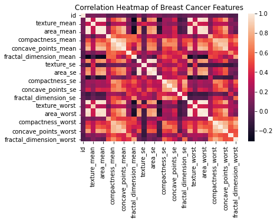

```python
coor_hm = sns.heatmap(df.corr())
coor_hm.set(title = "Correlation Heatmap of Breast Cancer Features")
```

Visualizing the correlation matrix at a glance using a heatmap

Lighter colors are more correlated, while darker colors are less correlated

# Identifying Correlation

Plotting some example variables together

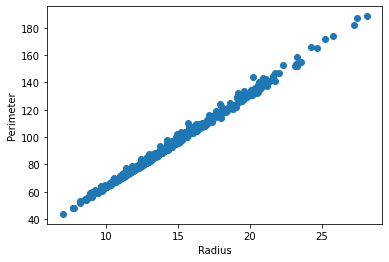

```python
#Plot radius vs perimeter
plt.scatter(df.radius_mean,df.perimeter_mean)
plt.xlabel("Radius")
plt.ylabel("Perimeter")
plt.show()
```

As expected these two features almost form a perfect line. As a result we may consider doing some dimensionality reduction and using only one of these features.

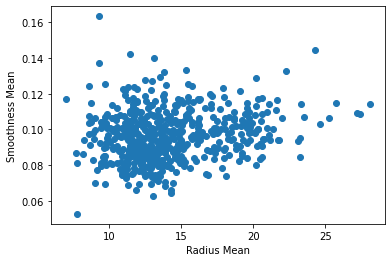

```python
#Plot radius vs smoothness
plt.scatter(df.radius_mean,df.smoothness_mean)
plt.xlabel("Radius Mean")
plt.ylabel("Smoothness Mean")
plt.show()
```

As expected these two features do not seem to form any uniform distribution.

# Model 1: Baseline with Logistic Regression

##### Split Data Set

```python
#Confirm the location and count of our outputs
df.diagnosis
```

```
0      M
1      M
2      M
3      M
4      M
      ..
564    M
565    M
566    M
567    M
568    B
Name: diagnosis, Length: 569, dtype: object
```

```python
#Assign the outputs as y and the features (remaining columns) as x

#Convert y, diagnosis from string to boolean
y = (df.diagnosis == 'M')
X = df.drop(["id","diagnosis"], axis=1)
```

```python
#Confirm results are what we expect for x and y

print(y.head())
print (X.head())
```

```
0    True
1    True
2    True
3    True
4    True
Name: diagnosis, dtype: bool
   radius_mean  texture_mean  perimeter_mean  area_mean  smoothness_mean  \
0        17.99         10.38          122.80     1001.0          0.11840
1        20.57         17.77          132.90     1326.0          0.08474
2        19.69         21.25          130.00     1203.0          0.10960
3        11.42         20.38           77.58      386.1          0.14250
4        20.29         14.34          135.10     1297.0          0.10030

   compactness_mean  concavity_mean  concave_points_mean  symmetry_mean  \
0           0.27760          0.3001              0.14710         0.2419
```

[output cut: 27 more lines]

```python
y.head()
```

```
0    True
1    True
2    True
3    True
4    True
Name: diagnosis, dtype: bool
```

```python
y=y.astype(int)
```

```python
#split data set setting aside 40% as test data
X_train, X_test, y_train, y_test = train_test_split(X, y, test_size=0.4, random_state=1234 )
```

If we want a CV set as well, simply split the 40% a second time to create a 60-20-20 split

```python
X_train.head()
```

|  | radius_mean | texture_mean | perimeter_mean | area_mean | smoothness_mean | compactness_mean | concavity_mean | concave_points_mean | symmetry_mean | fractal_dimension_mean | ... | radius_worst | texture_worst | perimeter_worst | area_worst | smoothness_worst | compactness_worst | concavity_worst | concave_points_worst | symmetry_worst | fractal_dimension_worst |
| --- | --- | --- | --- | --- | --- | --- | --- | --- | --- | --- | --- | --- | --- | --- | --- | --- | --- | --- | --- | --- | --- |
| 322 | 12.86 | 13.32 | 82.82 | 504.8 | 0.11340 | 0.08834 | 0.03800 | 0.03400 | 0.1543 | 0.06476 | ... | 14.04 | 21.08 | 92.80 | 599.5 | 0.15470 | 0.22310 | 0.17910 | 0.11550 | 0.2382 | 0.08553 |
| 93 | 13.45 | 18.30 | 86.60 | 555.1 | 0.10220 | 0.08165 | 0.03974 | 0.02780 | 0.1638 | 0.05710 | ... | 15.10 | 25.94 | 97.59 | 699.4 | 0.13390 | 0.17510 | 0.13810 | 0.07911 | 0.2678 | 0.06603 |
| 324 | 12.20 | 15.21 | 78.01 | 457.9 | 0.08673 | 0.06545 | 0.01994 | 0.01692 | 0.1638 | 0.06129 | ... | 13.75 | 21.38 | 91.11 | 583.1 | 0.12560 | 0.19280 | 0.11670 | 0.05556 | 0.2661 | 0.07961 |
| 407 | 12.85 | 21.37 | 82.63 | 514.5 | 0.07551 | 0.08316 | 0.06126 | 0.01867 | 0.1580 | 0.06114 | ... | 14.40 | 27.01 | 91.63 | 645.8 | 0.09402 | 0.19360 | 0.18380 | 0.05601 | 0.2488 | 0.08151 |
| 404 | 12.34 | 14.95 | 78.29 | 469.1 | 0.08682 | 0.04571 | 0.02109 | 0.02054 | 0.1571 | 0.05708 | ... | 13.18 | 16.85 | 84.11 | 533.1 | 0.10480 | 0.06744 | 0.04921 | 0.04793 | 0.2298 | 0.05974 |

5 rows × 30 columns

```python
y_test.head()
```

```
531    0
166    0
485    0
66     0
220    0
Name: diagnosis, dtype: int32
```

### Feature scaling

mean normalization & regularization to more accurately fit a model

scale all data, train and test data

```python
from sklearn.preprocessing import StandardScaler

scaler = preprocessing.StandardScaler().fit(X_train)
scaler
StandardScaler()
```

```
StandardScaler()
```

```python
X_train_scaled = scaler.transform(X_train)
X_train_scaled
```

```
array([[-0.38149076, -1.38902789, -0.39983422, ..., -0.03132519,
        -0.89029475,  0.0332247 ],
       [-0.21784157, -0.24464768, -0.24728547, ..., -0.57391176,
        -0.40780479, -0.94411495],
       [-0.56455596, -0.95471492, -0.59395048, ..., -0.92504982,
        -0.43551536, -0.2634856 ],
       ...,
       [-0.48966565, -0.17570911, -0.4696515 , ..., -0.24006968,
         0.13988653,  0.13196106],
       [ 1.10522056, -0.15272959,  1.11273905, ...,  0.22215027,
         0.15129676, -0.2504544 ],
       [-0.42032277, -1.28332209, -0.4418053 , ..., -0.80770559,
        -0.91148519, -0.78423221]])
```

```python
X_test_scaled = scaler.transform(X_test)
X_test_scaled
```

```
array([[-0.71156286,  0.15060011, -0.70694955, ..., -0.54274919,
         0.45285299,  0.23220103],
       [-0.95287608, -2.21858865, -0.96684741, ..., -1.06714518,
        -1.36626458, -0.39479995],
       [-0.49521308, -0.67896065, -0.39862351, ...,  0.24749782,
         0.49360383,  0.92886877],
       ...,
       [ 1.18011086, -0.42388795,  1.15309586, ...,  0.72611912,
        -0.68165044,  0.48029494],
       [-0.82528518,  0.10693901, -0.86474468, ..., -1.33120696,
        -0.60503886, -0.43790313],
       [ 1.169016  ,  0.58491308,  1.10870337, ...,  0.302666  ,
         0.29473972, -0.43940673]])
```

### Fit logistic regression model

```python
lr_model = LogisticRegressionCV(random_state=1234)
```

```python
lr_model.fit(X_train_scaled,y_train)
```

```
LogisticRegressionCV(random_state=1234)
```

```python
lr_model.get_params()
```

```
{'Cs': 10,
 'class_weight': None,
 'cv': None,
 'dual': False,
 'fit_intercept': True,
 'intercept_scaling': 1.0,
 'l1_ratios': None,
 'max_iter': 100,
 'multi_class': 'auto',
 'n_jobs': None,
 'penalty': 'l2',
 'random_state': 1234,
 'refit': True,
 'scoring': None,
 'solver': 'lbfgs',
 'tol': 0.0001,
 'verbose': 0}
```

```python
#scale test data to make predictions because the training set was also scaled
X_test_scaled = scaler.transform(X_test)
```

```python
#Use the scaled data to make predictions on whether the test examples will be benign or malignant
y_pred = lr_model.predict(X_test_scaled)
y_pred
```

```
array([0, 0, 0, 0, 0, 0, 1, 0, 1, 1, 1, 0, 0, 0, 0, 1, 0, 0, 0, 1, 0, 1,
       1, 1, 1, 0, 1, 0, 0, 0, 0, 0, 1, 0, 0, 0, 0, 1, 0, 0, 1, 0, 1, 0,
       0, 0, 0, 0, 1, 0, 0, 0, 0, 1, 1, 0, 0, 0, 0, 1, 0, 0, 0, 0, 0, 1,
       1, 0, 0, 0, 0, 1, 0, 0, 0, 0, 0, 1, 0, 1, 0, 0, 0, 0, 1, 1, 1, 1,
       0, 1, 0, 0, 0, 1, 1, 0, 0, 0, 0, 0, 1, 1, 0, 0, 1, 0, 0, 1, 1, 0,
       1, 0, 1, 1, 0, 0, 0, 1, 0, 1, 0, 0, 0, 0, 1, 0, 1, 1, 0, 0, 0, 0,
       1, 0, 0, 0, 0, 0, 0, 1, 0, 1, 1, 0, 1, 0, 0, 0, 1, 0, 0, 0, 1, 0,
       0, 0, 0, 1, 1, 0, 0, 0, 1, 0, 0, 1, 0, 0, 0, 0, 1, 0, 0, 1, 1, 0,
       0, 0, 0, 1, 0, 0, 0, 1, 0, 1, 0, 0, 0, 0, 1, 0, 0, 1, 1, 0, 1, 1,
       0, 0, 0, 0, 0, 1, 0, 0, 1, 0, 0, 0, 0, 1, 0, 0, 0, 0, 0, 0, 1, 0,
       0, 0, 1, 1, 0, 1, 0, 1])
```

```python
#See how close the model got to predicting
lr_accuracy_score = lr_model.score(X_test_scaled, y_test)
lr_accuracy_score
```

```
0.956140350877193
```

95.61% accurate on the test set. Would need to further discuss what an acceptable threshold for this value is.

On one hand, telling someone that their benign tumor is actually malignant can lead to a drastic response where it wouldn't be needed. On the other hand, people need to know whether to seek treatment or not with the information that their tumor is actually malignant.

```python
#Compare to the how well the model fits the training data
lr_model.score(X_train_scaled, y_train)
```

```
0.9912023460410557
```

99.12% accurate on the training set. As expected more accurate here than the test set.

# Model 2 Neural Net

```python
X_train.describe()
```

|  | radius_mean | texture_mean | perimeter_mean | area_mean | smoothness_mean | compactness_mean | concavity_mean | concave_points_mean | symmetry_mean | fractal_dimension_mean | ... | radius_worst | texture_worst | perimeter_worst | area_worst | smoothness_worst | compactness_worst | concavity_worst | concave_points_worst | symmetry_worst | fractal_dimension_worst |
| --- | --- | --- | --- | --- | --- | --- | --- | --- | --- | --- | --- | --- | --- | --- | --- | --- | --- | --- | --- | --- | --- |
| count | 341.000000 | 341.000000 | 341.000000 | 341.000000 | 341.000000 | 341.000000 | 341.000000 | 341.00000 | 341.000000 | 341.000000 | ... | 341.000000 | 341.000000 | 341.000000 | 341.000000 | 341.000000 | 341.000000 | 341.000000 | 341.000000 | 341.000000 | 341.000000 |
| mean | 14.235378 | 19.364633 | 92.727478 | 666.362757 | 0.096371 | 0.105316 | 0.091355 | 0.04983 | 0.182095 | 0.062733 | ... | 16.402710 | 25.927654 | 108.402581 | 895.107918 | 0.133289 | 0.264462 | 0.287925 | 0.117601 | 0.292818 | 0.084867 |
| std | 3.610571 | 4.358095 | 24.815378 | 362.403166 | 0.014282 | 0.052911 | 0.079349 | 0.03920 | 0.026128 | 0.007186 | ... | 4.909726 | 6.317725 | 34.253667 | 570.480168 | 0.023967 | 0.171489 | 0.224550 | 0.067166 | 0.061439 | 0.019981 |
| min | 6.981000 | 10.720000 | 43.790000 | 143.500000 | 0.052630 | 0.019380 | 0.000000 | 0.00000 | 0.106000 | 0.049960 | ... | 7.930000 | 12.490000 | 50.410000 | 185.200000 | 0.081250 | 0.034320 | 0.000000 | 0.000000 | 0.156500 | 0.055040 |
| 25% | 11.850000 | 15.940000 | 76.370000 | 432.200000 | 0.086050 | 0.066690 | 0.029660 | 0.02068 | 0.163300 | 0.057660 | ... | 13.140000 | 21.080000 | 85.080000 | 525.100000 | 0.117800 | 0.150600 | 0.116700 | 0.064980 | 0.255200 | 0.071270 |
| 50% | 13.300000 | 18.900000 | 86.490000 | 546.100000 | 0.094950 | 0.094860 | 0.065050 | 0.03390 | 0.180100 | 0.061270 | ... | 14.840000 | 25.730000 | 97.650000 | 675.200000 | 0.131200 | 0.217000 | 0.241300 | 0.101500 | 0.284400 | 0.080040 |
| 75% | 16.070000 | 21.970000 | 105.800000 | 800.000000 | 0.105400 | 0.131800 | 0.142500 | 0.07944 | 0.196400 | 0.066120 | ... | 19.380000 | 30.360000 | 128.800000 | 1165.000000 | 0.146700 | 0.345800 | 0.400000 | 0.170800 | 0.320000 | 0.092700 |
| max | 28.110000 | 33.810000 | 188.500000 | 2499.000000 | 0.142500 | 0.311400 | 0.426400 | 0.19130 | 0.274300 | 0.097440 | ... | 33.130000 | 49.540000 | 229.300000 | 3234.000000 | 0.222600 | 1.058000 | 1.252000 | 0.291000 | 0.663800 | 0.207500 |

8 rows × 30 columns

```python
X_train, X_test, y_train, y_test = train_test_split(X, y, test_size=0.4, random_state=1234 )
```

```python
#print('y currently uses string variables, which cannot be put into a sigmoid function\n')
#print(y_train.head())


#convert y to binary encoding for neural net
#y_train_binary = pd.get_dummies(y_train)
#print('\ny_train to binary')
#print(y_train_binary.head())
#print(y_train_binary.shape)

#y_test_binary = pd.get_dummies(y_test)
#print('\ny_test to binary')
#print(y_test_binary.head())
#print(y_test_binary.shape)
```

```python
y_train
```

```
322    0
93     0
324    0
407    0
404    0
      ..
279    0
372    1
204    0
53     1
294    0
Name: diagnosis, Length: 341, dtype: int32
```

```python
#input_shape=X_train.shape[1]

model = tf.keras.Sequential([
    layers.Dense(units=256, activation='relu', input_shape=[30]),
    layers.Dense(units=256, activation='relu'),
    layers.Dense(units=256, activation='relu'),
    layers.Dense(units=1, activation='sigmoid'),
])

model.compile(
    optimizer = 'adam',
    loss = 'binary_crossentropy',
    metrics = ['binary_accuracy']
)
```

```python
history = model.fit(X_train_scaled, y_train,
                    validation_data=(X_test_scaled, y_test),
                    batch_size= 128,
                    epochs=100,
                   )
```

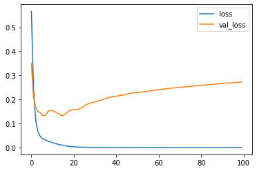

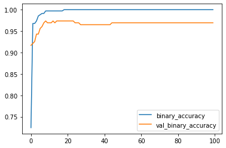

```python
#plot learning
history_df=pd.DataFrame(history.history)
history_df.loc[:,['loss','val_loss']].plot()

history_df.loc[:,['binary_accuracy','val_binary_accuracy']].plot()
```

```python
score_nn = history_df.loc[:,['val_binary_accuracy']]
nn_accuracy_score = score_nn.iloc[-1,-1]
nn_accuracy_score
```

```
0.969298243522644
```

```python
cross_val_score(estimator = model, scoring('accuracy',X_train_scaled, y_test))
```

[output not shown]

note that the validation loss in the first graph is increasing quite a bit, so it would be good to implement some early stopping to prevent the model from overfitting the test data.

since the goal of this project is to gather insights from the data as opposed to optimizing a model, this will be left as a keynote for future work.

## Model 3 & 4 Random Forest Model

```python
model_rf = RandomForestClassifier(n_estimators=1000, random_state=1234).fit(X_train_scaled, y_train)
y_pred_rf=model_rf.predict(X_test_scaled)
rf_accuracy_score = accuracy_score(y_pred_rf, y_test)
rf_accuracy_score
```

```
0.9254385964912281
```

```python
print(classification_report(y_pred_rf, y_test))
```

```
              precision    recall  f1-score   support

           0       0.96      0.93      0.94       149
           1       0.87      0.92      0.90        79

    accuracy                           0.93       228
   macro avg       0.91      0.93      0.92       228
weighted avg       0.93      0.93      0.93       228
```

### Trying a boosted ensemble to see if there is any improvement

```python
model_xgb = XGBClassifier()
model_xgb.fit(X_train_scaled, y_train)
y_pred_xgb = model_xgb.predict(X_test_scaled)
xgb_accuracy_score = accuracy_score(y_pred_xgb, y_test)
xgb_accuracy_score
```

```
0.9385964912280702
```

```python
print(classification_report(y_pred_xgb, y_test))
```

```
              precision    recall  f1-score   support

           0       0.96      0.95      0.95       146
           1       0.90      0.93      0.92        82

    accuracy                           0.94       228
   macro avg       0.93      0.94      0.93       228
weighted avg       0.94      0.94      0.94       228
```

# Model Comparison

```python
df.value_counts(subset='diagnosis')
```

```
diagnosis
B    357
M    212
dtype: int64
```

Since there are a comparable number of M and B cases in the data, it is ok to simply use accuracy when evaluating each model, as neither class is extremely rare.

```python
accuracy_scores = {'model': ['Logistic Regression', 'Neural Network', 'Random Forest', ' Boosted Forest Ensemble'],
                   'accuracy score': [lr_accuracy_score, nn_accuracy_score, rf_accuracy_score, xgb_accuracy_score]
                  }
accuracy_scores_df = pd.DataFrame(accuracy_scores)

accuracy_scores_df
```

|  | model | accuracy score |
| --- | --- | --- |
| 0 | Logistic Regression | 0.956140 |
| 1 | Neural Network | 0.969298 |
| 2 | Random Forest | 0.925439 |
| 3 | Boosted Forest Ensemble | 0.938596 |

Among these models, the neural network and logistic regression model were the most accurate. It would be best to use these models when gathering insights from the features.

# Interpreting the Model

how do we know which features are most important?

Start with Feature importance, which tells us *which* features are most important

Follow up with SHAP values which tell us *how* each feature effects the prediction

```python
#y_test_df = pd.DataFrame(y_test)
#y_test_df
#X_test_s_df = pd.DataFrame(X_test_scaled)
```

https://eli5.readthedocs.io/en/latest/autodocs/sklearn.html#eli5.sklearn.permutation_importance.PermutationImportance

https://eli5.readthedocs.io/en/latest/blackbox/permutation_importance.html

```python
import eli5
from eli5.sklearn import PermutationImportance
#perm = PermutationImportance(estimator=model, scoring='accuracy', random_state=1234).fit(X_test_scaled,y_test)

perm_lr = PermutationImportance(estimator=lr_model, scoring='accuracy', random_state=1234).fit(X_test_scaled,y_test)
```

```python
#view weights
features=X_train.columns.tolist()
eli5.show_weights(perm_lr, top=len(X_train.columns),feature_names=features, )
```

| Weight | Feature |
| --- | --- |
| 0.0132 ± 0.0184 | texture_worst |
| 0.0132 ± 0.0096 | radius_se |
| 0.0096 ± 0.0140 | texture_mean |
| 0.0088 ± 0.0096 | radius_mean |
| 0.0079 ± 0.0102 | concave_points_mean |
| 0.0079 ± 0.0187 | radius_worst |
| 0.0070 ± 0.0089 | area_se |
| 0.0070 ± 0.0131 | perimeter_worst |
| 0.0061 ± 0.0131 | concavity_worst |
| 0.0061 ± 0.0089 | fractal_dimension_mean |
| 0.0053 ± 0.0035 | area_worst |
| 0.0053 ± 0.0066 | smoothness_worst |
| 0.0044 ± 0.0055 | fractal_dimension_se |
| 0.0035 ± 0.0066 | perimeter_mean |
| 0.0035 ± 0.0066 | symmetry_worst |
| 0.0035 ± 0.0151 | concave_points_worst |
| 0.0026 ± 0.0043 | compactness_se |
| 0.0026 ± 0.0172 | perimeter_se |
| 0.0018 ± 0.0089 | concavity_mean |
| 0.0009 ± 0.0035 | concave_points_se |
| 0.0009 ± 0.0035 | compactness_worst |
| 0 ± 0.0000 | compactness_mean |
| -0.0009 ± 0.0035 | texture_se |
| -0.0009 ± 0.0066 | smoothness_mean |
| -0.0018 ± 0.0070 | area_mean |
| -0.0018 ± 0.0043 | smoothness_se |
| -0.0026 ± 0.0105 | symmetry_se |
| -0.0035 ± 0.0035 | symmetry_mean |
| -0.0044 ± 0.0000 | concavity_se |
| -0.0044 ± 0.0096 | fractal_dimension_worst |

## SHAP Values

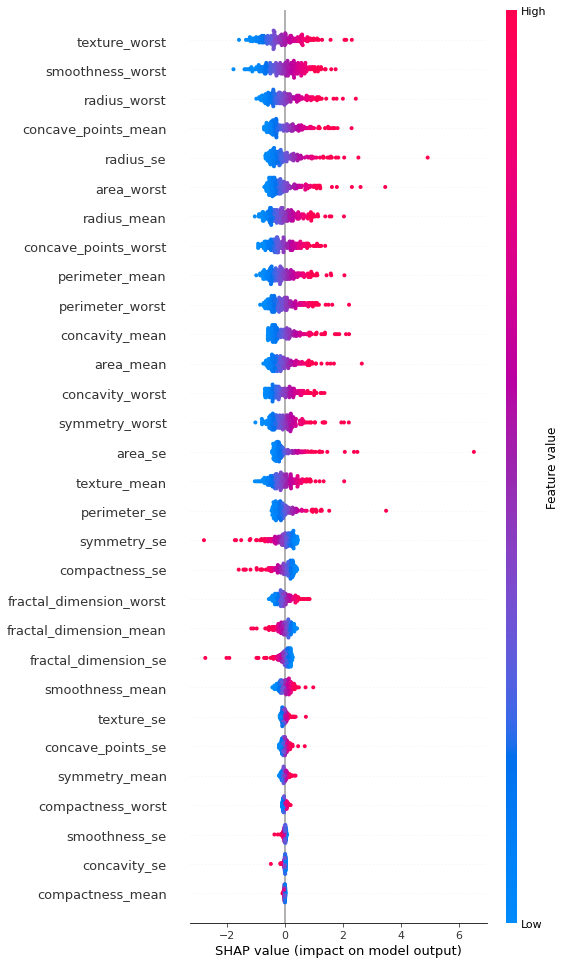

```python
#explainer = shap.LinearExplainer(lr_model, X_train_scaled, X_test_scaled)
explainer = shap.LinearExplainer(lr_model, X_train_scaled)
shap_values=explainer.shap_values(X_test_scaled)
shap.summary_plot(shap_values, X_test_scaled, feature_names=features, max_display=len(X_train.columns))
```

```python
shap.force_plot(explainer)
```

## Using our findings: 2D PDP plot

#### With feature importance and SHAP values, we are able to visual confidence intervals for specfic features or combinations of features

```python
#array to dataframe
X_test_df = pd.DataFrame(X_test_scaled, columns=features)
X_test_df.head()
```

|  | radius_mean | texture_mean | perimeter_mean | area_mean | smoothness_mean | compactness_mean | concavity_mean | concave_points_mean | symmetry_mean | fractal_dimension_mean | ... | radius_worst | texture_worst | perimeter_worst | area_worst | smoothness_worst | compactness_worst | concavity_worst | concave_points_worst | symmetry_worst | fractal_dimension_worst |
| --- | --- | --- | --- | --- | --- | --- | --- | --- | --- | --- | --- | --- | --- | --- | --- | --- | --- | --- | --- | --- | --- |
| 0 | -0.711563 | 0.150600 | -0.706950 | -0.691303 | 0.366704 | -0.204151 | -0.622908 | -0.721975 | 0.145854 | 0.261558 | ... | -0.622682 | 0.456902 | -0.625744 | -0.604779 | 0.907210 | 0.186514 | -0.054077 | -0.542749 | 0.452853 | 0.232201 |
| 1 | -0.952876 | -2.218589 | -0.966847 | -0.853239 | -0.030190 | -0.907683 | -0.833553 | -0.839238 | -1.686288 | 0.176551 | ... | -0.979641 | -2.204605 | -1.015764 | -0.844578 | 0.430850 | -0.810347 | -0.817164 | -1.067145 | -1.366265 | -0.394800 |
| 2 | -0.495213 | -0.678961 | -0.398624 | -0.524116 | -0.086288 | 0.866573 | 0.795698 | -0.035003 | 1.000598 | 1.465581 | ... | -0.534972 | -0.776363 | -0.309401 | -0.552114 | -0.659764 | 0.827144 | 0.899446 | 0.247498 | 0.493604 | 0.928869 |
| 3 | -1.323167 | 0.378097 | -1.316337 | -1.096972 | 0.563047 | -0.522131 | -0.878863 | -0.888800 | -0.398423 | 0.871931 | ... | -1.222373 | 0.892825 | -1.209604 | -0.990810 | 0.898853 | -0.572666 | -0.864350 | -0.781762 | -0.081798 | 0.363014 |
| 4 | -0.162367 | -1.425795 | -0.195629 | -0.269330 | 0.006274 | -0.344592 | -0.662286 | -0.618252 | -1.766779 | 0.098513 | ... | -0.216768 | -1.518225 | -0.254144 | -0.331625 | -0.091475 | -0.099638 | -0.499620 | -0.552292 | -0.893555 | 0.115923 |

5 rows × 30 columns

### Here, two features with high SHAP values were chosen. From the SHAP summary plot, the red and blue sections are roughly equal, which respectively increase and decrease the prediction

```
<function matplotlib.pyplot.show(close=None, block=None)>
```

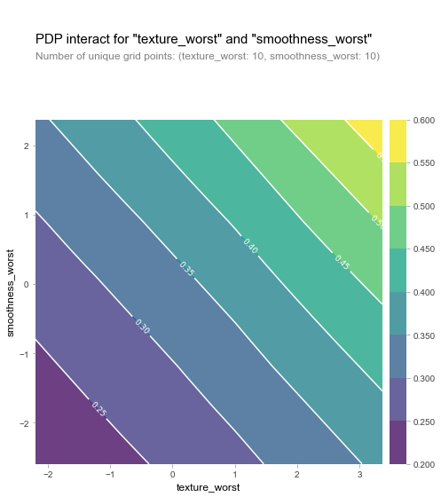

```python
features_to_plot = ['texture_worst', 'smoothness_worst']

X_test_df = pd.DataFrame(X_test_df, columns=features)

interact_plot = pdp.pdp_interact(model = lr_model, dataset=X_test_df, model_features=features, features=features_to_plot)

pdp.pdp_interact_plot(pdp_interact_out=interact_plot, feature_names=features_to_plot, plot_type='contour')

plt.show
```

### Next plot has one feature outlined as very important, and one feature that contributes very little to the model prediction

```
<function matplotlib.pyplot.show(close=None, block=None)>
```

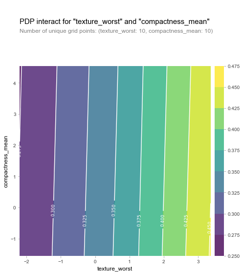

```python
features_to_plot_2 = ['texture_worst', 'compactness_mean']

X_test_df = pd.DataFrame(X_test_df, columns=features)

interact_plot = pdp.pdp_interact(model = lr_model, dataset=X_test_df, model_features=features, features=features_to_plot_2)

pdp.pdp_interact_plot(pdp_interact_out=interact_plot, feature_names=features_to_plot_2, plot_type='contour')

plt.show
```

As expected, as compactness_mean chances, there is almost no impact to the prediction, while changes in texture_worst make all the difference.

### Lastly, two features from the SHAP summary plot that most strongly increase the prediction

```
<function matplotlib.pyplot.show(close=None, block=None)>
```

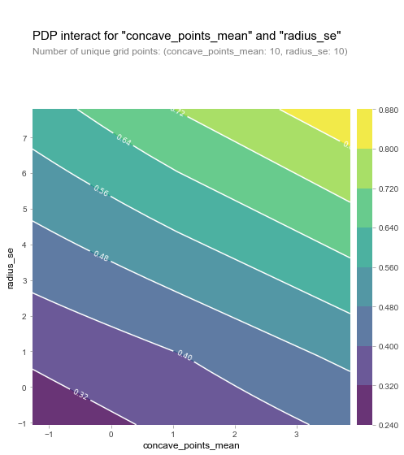

```python
features_to_plot_3 = ['concave_points_mean', 'radius_se']

X_test_df = pd.DataFrame(X_test_df, columns=features)

interact_plot = pdp.pdp_interact(model = lr_model, dataset=X_test_df, model_features=features, features=features_to_plot_3)

pdp.pdp_interact_plot(pdp_interact_out=interact_plot, feature_names=features_to_plot_3, plot_type='contour')

plt.show
```

Using only two features out of the entire list, there are certain values where the model is over 80% sure that a cancer is malignant(!)

```
(<Figure size 540x684 with 3 Axes>,
 {'title_ax': <AxesSubplot:>,
  'pdp_inter_ax': <AxesSubplot:xlabel='compactness_se', ylabel='fractal_dimension_se'>})
```

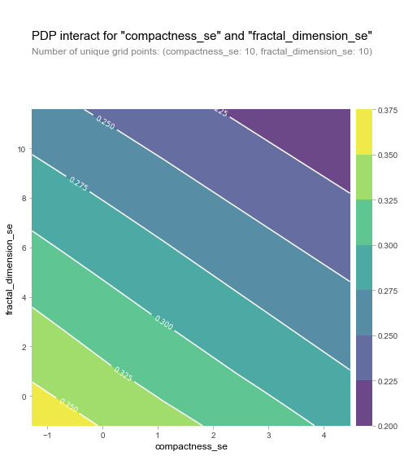

```python
features_to_plot_4 = ['compactness_se', 'fractal_dimension_se']

X_test_df = pd.DataFrame(X_test_df, columns=features)

interact_plot = pdp.pdp_interact(model = lr_model, dataset=X_test_df, model_features=features, features=features_to_plot_4)

pdp.pdp_interact_plot(pdp_interact_out=interact_plot, feature_names=features_to_plot_4, plot_type='contour')
```

likewise it is possible to generate a graph with the opposite trend, using the values to identify featues that drive the prediction strongly downwards. The higher these features, the more likely that the cancer is not malignant (is benign).

# SHAP Graph for an Individual Row

```python
# Each row represents a patient
arbitrary_row_number = 100
single_row = X_test_df.iloc[arbitrary_row_number]
single_row
```

```
radius_mean                1.654416
texture_mean               1.715506
perimeter_mean             1.653520
area_mean                  1.568616
smoothness_mean            0.187892
compactness_mean           1.165626
concavity_mean             0.918122
concave_points_mean        1.958723
symmetry_mean              0.207181
fractal_dimension_mean    -0.352996
radius_se                  2.075985
texture_se                 1.189661
perimeter_se               2.051359
area_se                    1.455238
smoothness_se              0.504635
compactness_se             1.158000
concavity_se               0.989293
concave_points_se          2.261266
symmetry_se                2.114424
fractal_dimension_se       0.229455
radius_worst               1.588426
texture_worst              1.249489
perimeter_worst            1.508546
area_worst                 1.362067
smoothness_worst          -0.229368
compactness_worst          0.450475
concavity_worst            0.367382
concave_points_worst       1.455234
symmetry_worst             0.558805
fractal_dimension_worst   -0.428380
Name: 100, dtype: float64
```

```python
single_row_array = single_row.values.reshape(1,-1)
print(single_row_array)
model.predict(single_row_array)
```

```
[[ 1.65441615  1.71550558  1.65352032  1.56861596  0.18789155  1.16562604
   0.91812185  1.95872261  0.20718065 -0.35299626  2.07598525  1.18966091
   2.05135855  1.45523797  0.50463546  1.1580004   0.98929296  2.26126643
   2.11442408  0.22945526  1.58842562  1.24948918  1.50854627  1.36206709
  -0.22936818  0.45047451  0.36738198  1.45523381  0.55880518 -0.42838034]]
```

```
array([[1.]], dtype=float32)
```

```python
shap_values_row = explainer.shap_values(single_row_array)
shap_values_row
```

```
array([[ 0.91757688,  0.7537553 ,  0.89105976,  0.81221005,  0.06999469,
        -0.02004533,  0.49581129,  1.18549732,  0.01262738,  0.08341577,
         1.31430787,  0.13205967,  0.94021343,  0.82262189, -0.0199686 ,
        -0.42117035, -0.03592195,  0.2290369 , -0.81082809, -0.06233686,
         0.96564244,  0.83663497,  0.79691281,  0.79387181, -0.09012786,
         0.03600651,  0.24353704,  0.79803804,  0.27780599, -0.13948407]])
```

```python
shap.initjs()
shap.force_plot(explainer.expected_value, shap_values=shap_values_row, feature_names=features)
```

[output not shown]

Exploration of the prediction for a single patient based on the features. This explanation was made for an existing patient, but can easily be used for future patients by using the model to predict for a new row of data.

As determined in the SHAP values above, symmetry and compactness are two major features that drive the prediction downward, while features related to size such as radius and perimeter greatly drive the prediction upward. This is in line with expectations.

For this individual patient, the prediction is much higher than the base value. Based on the feature values, the model predicts that this particular cancer is malignant.

# Results

- Trained models & compared to select the model with best performance to make future predictions with for individual patients, or to further optimize as desired
- Used heatmap to visualize correlation between features, and set up a good starting point for feature engineering to further push better model performance
- Ran Permutation Importance to identify the most impactful features. Likewise, some features actually turn out to be rather useless.
- Used SHAP values and convienent visuals to easily identify the features that strongly increase or decrease the diagnosis prediction and explore their contribution
- Extended the usage of SHAP values to individual patients and cancers, visualizing with all features at once to show how the overall prediction is obtained